# Labo — De la causalité à la modélisation

Formation régionale UEMOA · Ouagadougou · Mercredi 25 novembre 2026

Vissého Adjiwanou (UQAM)

# 1 Ce que vous allez faire

Ce labo prolonge le cours du matin. Il pose toujours la même question : **le traitement a-t-il un effet, et de combien ?** Il y répond avec trois types de données, de la plus favorable à la plus courante dans nos instituts.

| Partie | Données | Ce que l’on apprend | Durée |
| --- | --- | --- | --- |
| A. L’expérience | CV fictifs envoyés à des employeurs (Bertrand et Mullainathan, 2004) | Avec le hasard, une simple différence de moyennes suffit | 15 min |
| B. Une expérience naturelle | Salaire minimum au New Jersey et en Pennsylvanie (Card et Krueger, 1994) | Comparer dans le temps et entre groupes : la double différence | 15 min |
| C. Une vraie EDS | CPN et accouchement assisté, Ghana rural 2003 (Adjiwanou et LeGrand, 2013) | Confusion, régression logistique, effet marginal, mauvais contrôle, effets fixes, variable instrumentale | 40 min |
| D. Pour aller plus loin | Les mêmes données | Prédire n’est pas expliquer | 10 min |

**La partie C reprend les données de l’article d’Adjiwanou et LeGrand (2013)** : l’EDS du Ghana de 2003, femmes rurales ayant eu une naissance dans les cinq années précédant l’enquête. La question : les consultations prénatales (CPN) augmentent-elles le recours à un accouchement assisté par du personnel qualifié ? Avec de vraies données, **personne ne connaît le vrai effet**. Nous verrons comment l’estimation bouge d’une méthode à l’autre, et ce que chaque méthode suppose.

**Les microdonnées EDS ne sont pas fournies avec ce labo.** Chaque participant télécharge lui-même le fichier « Individual Recode » au format Stata (`GHIR4BFL.DTA`) depuis son compte sur dhsprogram.com et le place dans le dossier `donnees/`. Les conditions d’utilisation des EDS interdisent de redistribuer les fichiers.

# 2 Préparation

```r
library(tidyverse)
library(broom)
library(haven)    # lire les fichiers Stata des EDS
library(fixest)   # variables instrumentales
```

```r
resume  <- read_csv("donnees/resume.csv")
minwage <- read_csv("donnees/minwage.csv")
```

La fonction ci-dessous prépare le fichier d’analyse à partir du fichier IR brut. Elle utilise les noms de variables standard des EDS ; elle peut donc servir pour l’EDS de votre pays, en vérifiant les catégories de `m3a` à `m3n` (personnel qualifié) qui changent d’un pays à l’autre.

```r
preparer_eds <- function(fichier) {
  read_dta(fichier,
           col_select = c(v001, v005, v012, v024, v025, v106, v190, v201,
                          v467d, v158, m14_1, m13_1, m3a_1, m3b_1, m3c_1, m15_1)) %>%
    # femmes rurales, dernière naissance des 5 dernières années
    filter(v025 == 2, !is.na(m14_1), m14_1 < 98) %>%
    transmute(
      grappe       = v001,
      region       = as_factor(v024),
      # résultat : médecin, infirmière/sage-femme ou sage-femme auxiliaire
      acc_assiste  = as.integer(m3a_1 == 1 | m3b_1 == 1 | m3c_1 == 1),
      # traitement : au moins 4 CPN
      cpn4         = as.integer(m14_1 >= 4),
      # première CPN au cours des 3 premiers mois (0 si aucune CPN)
      cpn_precoce  = case_when(m14_1 == 0 ~ 0L, m13_1 <= 3 ~ 1L, m13_1 <= 10 ~ 0L),
      # lieu d'accouchement : établissement de santé (codes 20 à 96)
      centre_sante = as.integer(m15_1 >= 20 & m15_1 < 97),
      age          = v012,
      instruction  = factor(pmin(as.numeric(v106), 2), 0:2,
                            c("aucune", "primaire", "secondaire+")),
      quintile     = as_factor(v190),
      parite       = cut(v201, c(0, 1, 3, 5, Inf), c("1", "2-3", "4-5", "6+")),
      distance_pb  = as.integer(v467d == 1),   # la distance est un « gros problème »
      radio        = as.integer(v158 >= 1 & v158 < 9)
    ) %>%
    drop_na()
}

eds <- preparer_eds("donnees/GHIR4BFL.DTA")
nrow(eds)
```

```
## [1] 1886
```

# 3 Partie A — L’expérience : discrimination à l’embauche

Des chercheurs ont répondu à des offres d’emploi à Boston et à Chicago avec des CV fictifs. Seul le **prénom** changeait : un prénom à consonance afro-américaine (Lakisha, Jamal) ou blanche (Emily, Greg). Le prénom a été attribué **au hasard** à chaque CV. La variable `call` vaut 1 si l’employeur a rappelé.

```r
resume %>% count(race, sex)
```

```
## # A tibble: 4 × 3
##   race  sex        n
##   <chr> <chr>  <int>
## 1 black female  1886
## 2 black male     549
## 3 white female  1860
## 4 white male     575
```

## 3.1 L’effet causal est une différence de moyennes

```r
taux_rappel <- resume %>%
  group_by(race) %>%
  summarise(taux_rappel = mean(call))
taux_rappel
```

```
## # A tibble: 2 × 2
##   race  taux_rappel
##   <chr>       <dbl>
## 1 black      0.0645
## 2 white      0.0965
```

```r
taux_rappel %>%
  pivot_wider(names_from = race, values_from = taux_rappel) %>%
  mutate(effet = black - white)
```

```
## # A tibble: 1 × 3
##    black  white   effet
##    <dbl>  <dbl>   <dbl>
## 1 0.0645 0.0965 -0.0320
```

Le prénom afro-américain réduit le taux de rappel d’environ 3 points de pourcentage (6,4 % contre 9,7 %).

## 3.2 Les deux groupes étaient-ils comparables ?

Le hasard rend les groupes semblables **en moyenne**, sur ce qu’on observe comme sur ce qu’on n’observe pas. On le vérifie sur les variables observées : c’est la **vérification de l’équilibre**.

```r
resume %>%
  group_by(race) %>%
  summarise(part_femmes = mean(sex == "female"))
```

```
## # A tibble: 2 × 2
##   race  part_femmes
##   <chr>       <dbl>
## 1 black       0.775
## 2 white       0.764
```

## 3.3 La même chose avec une régression

```r
lm(call ~ race, data = resume) %>% tidy()
```

```
## # A tibble: 2 × 5
##   term        estimate std.error statistic  p.value
##   <chr>          <dbl>     <dbl>     <dbl>    <dbl>
## 1 (Intercept)   0.0645   0.00550     11.7  2.87e-31
## 2 racewhite     0.0320   0.00778      4.11 3.94e- 5
```

Le coefficient de `racewhite` est exactement la différence de moyennes. **Dans une expérience, la régression ne fait rien de plus qu’une soustraction.**

> **À vous (1).** Ajoutez `sex` au modèle. Le coefficient de `race` change-t-il beaucoup ? Pourquoi est-ce attendu dans une expérience ?

# 4 Partie B — Une expérience naturelle : le salaire minimum

En 1992, le New Jersey a relevé son salaire minimum de 4,25 à 5,05 dollars ; la Pennsylvanie voisine ne l’a pas fait. Card et Krueger ont interrogé des restaurants de restauration rapide des deux États avant et après la hausse. La théorie économique classique prédit une baisse de l’emploi. Nous mesurons la part des emplois à temps plein.

```r
minwage <- minwage %>%
  mutate(etat       = if_else(location == "PA", "Pennsylvanie", "New Jersey"),
         part_avant = fullBefore / (fullBefore + partBefore),
         part_apres = fullAfter  / (fullAfter  + partAfter))

resultats <- minwage %>%
  group_by(etat) %>%
  summarise(avant = mean(part_avant, na.rm = TRUE),
            apres = mean(part_apres, na.rm = TRUE))
resultats
```

```
## # A tibble: 2 × 3
##   etat         avant apres
##   <chr>        <dbl> <dbl>
## 1 New Jersey   0.297 0.320
## 2 Pennsylvanie 0.310 0.272
```

## 4.1 Trois façons de construire le contrefactuel

```r
nj <- resultats %>% filter(etat == "New Jersey")
pa <- resultats %>% filter(etat == "Pennsylvanie")

tibble(
  methode = c("Comparaison transversale (après)",
              "Avant-après (New Jersey seul)",
              "Double différence"),
  estimation = c(nj$apres - pa$apres,
                 nj$apres - nj$avant,
                 (nj$apres - nj$avant) - (pa$apres - pa$avant)),
  hypothese = c("Les deux États sont comparables",
                "Rien d'autre n'a changé dans le temps",
                "Sans la hausse, les deux États auraient évolué en parallèle")
)
```

```
## # A tibble: 3 × 3
##   methode                          estimation hypothese
##   <chr>                                 <dbl> <chr>
## 1 Comparaison transversale (après)     0.0481 Les deux États sont comparables
## 2 Avant-après (New Jersey seul)        0.0239 Rien d'autre n'a changé dans le t…
## 3 Double différence                    0.0616 Sans la hausse, les deux États au…
```

## 4.2 La double différence est une régression avec interaction

```r
minwage_long <- minwage %>%
  select(etat, part_avant, part_apres) %>%
  pivot_longer(c(part_avant, part_apres), names_to = "periode", values_to = "part_temps_plein") %>%
  mutate(nj    = as.integer(etat == "New Jersey"),
         apres = as.integer(periode == "part_apres"))

lm(part_temps_plein ~ nj * apres, data = minwage_long) %>% tidy()
```

```
## # A tibble: 4 × 5
##   term        estimate std.error statistic  p.value
##   <chr>          <dbl>     <dbl>     <dbl>    <dbl>
## 1 (Intercept)   0.310     0.0295    10.5   4.11e-24
## 2 nj           -0.0134    0.0327    -0.411 6.81e- 1
## 3 apres        -0.0377    0.0417    -0.903 3.67e- 1
## 4 nj:apres      0.0616    0.0463     1.33  1.84e- 1
```

Le coefficient de l’interaction `nj:apres` est l’estimation par double différence.

> **À vous (2).** Quelle est l’hypothèse qui rend la double différence crédible ? Avec quelles données pourrait-on la vérifier ? Pensez à une politique de votre pays qui a été appliquée dans certaines régions et pas dans d’autres (gratuité des soins, gratuité scolaire) : comment l’évalueriez-vous de la même manière ?

# 5 Partie C — Une vraie EDS : CPN et accouchement assisté au Ghana rural

| Variable | Contenu |
| --- | --- |
| `grappe` | numéro de la grappe (unité primaire de sondage) |
| `region` | région |
| `cpn4` | **traitement** : au moins 4 consultations prénatales pour la dernière naissance |
| `acc_assiste` | **résultat** : accouchement assisté par du personnel qualifié |
| `cpn_precoce` | première CPN dans les 3 premiers mois de grossesse |
| `centre_sante` | a accouché dans un établissement de santé |
| `instruction`, `quintile` | niveau d’instruction et quintile de bien-être |
| `age`, `parite` | âge de la femme et nombre d’enfants nés vivants |
| `distance_pb` | la distance au centre de santé est un « gros problème » |
| `radio` | écoute la radio au moins de temps en temps |

Les régressions de ce labo ne sont pas pondérées : on cherche un effet, pas un niveau national. Pour un indicateur descriptif, on utiliserait le poids d’échantillonnage (`v005`).

## 5.1 C1. La comparaison naïve

```r
eds %>%
  group_by(cpn4) %>%
  summarise(n = n(), acc_assiste = mean(acc_assiste))
```

```
## # A tibble: 2 × 3
##    cpn4     n acc_assiste
##   <int> <int>       <dbl>
## 1     0   689       0.119
## 2     1  1197       0.400
```

```r
naif <- eds %>%
  summarise(effet = mean(acc_assiste[cpn4 == 1]) - mean(acc_assiste[cpn4 == 0])) %>%
  pull(effet)
naif
```

```
## [1] 0.281154
```

Les femmes qui ont eu au moins 4 CPN accouchent beaucoup plus souvent avec du personnel qualifié (40 % contre 12 %). Mais sont-elles comparables aux autres ?

## 5.2 C2. Les groupes ne sont pas comparables : la confusion

```r
eds %>%
  group_by(cpn4) %>%
  summarise(secondaire  = mean(instruction == "secondaire+"),
            plus_riches = mean(quintile %in% c("richer", "richest")),
            distance_pb = mean(distance_pb),
            radio       = mean(radio),
            age         = mean(age))
```

```
## # A tibble: 2 × 6
##    cpn4 secondaire plus_riches distance_pb radio   age
##   <int>      <dbl>       <dbl>       <dbl> <dbl> <dbl>
## 1     0      0.173      0.0377       0.602 0.702  30.5
## 2     1      0.287      0.102        0.501 0.830  30.6
```

Les femmes qui font 4 CPN sont plus instruites, plus riches, moins gênées par la distance et plus exposées aux médias. Ces mêmes facteurs favorisent aussi l’accouchement assisté : ce sont des **facteurs de confusion**. La comparaison naïve mélange l’effet des CPN et l’effet de ces différences.

> **À vous (3).** Dessinez sur papier le graphe causal (DAG) : CPN, accouchement assisté, instruction, richesse, distance, radio. Ajoutez une variable que l’EDS ne mesure pas. Où se place-t-elle ?

## 5.3 C3. La régression logistique : comparer à caractéristiques égales

```r
controles <- ~ age + instruction + quintile + parite + distance_pb + radio + region

m0 <- glm(acc_assiste ~ cpn4, family = binomial, data = eds)
m1 <- glm(update(controles, acc_assiste ~ cpn4 + .), family = binomial, data = eds)

bind_rows(
  tidy(m0, exponentiate = TRUE, conf.int = TRUE) %>% mutate(modele = "Sans contrôle"),
  tidy(m1, exponentiate = TRUE, conf.int = TRUE) %>% mutate(modele = "Avec contrôles")
) %>%
  filter(term == "cpn4") %>%
  select(modele, rapport_de_cotes = estimate, conf.low, conf.high)
```

```
## # A tibble: 2 × 4
##   modele         rapport_de_cotes conf.low conf.high
##   <chr>                     <dbl>    <dbl>     <dbl>
## 1 Sans contrôle              4.94     3.83      6.43
## 2 Avec contrôles             4.20     3.20      5.57
```

Le **rapport de cotes** (*odds ratio*) diminue quand on contrôle les facteurs de confusion observés. Mais un rapport de cotes de 4 ne veut pas dire « quatre fois plus de chances » : il porte sur les cotes, pas sur les probabilités. Pour un décideur, il faut un effet en **points de pourcentage**.

## 5.4 C4. De la cote à l’effet : le contrefactuel par prédiction

On utilise le modèle pour prédire, pour **chaque femme**, la probabilité d’accouchement assisté si elle avait eu 4 CPN, puis si elle ne les avait pas eues. La moyenne des différences est l’**effet moyen** (cette méthode s’appelle la *g-computation* ou standardisation par le modèle).

```r
effet_moyen <- function(modele, donnees) {
  p1 <- predict(modele, newdata = donnees %>% mutate(cpn4 = 1), type = "response")
  p0 <- predict(modele, newdata = donnees %>% mutate(cpn4 = 0), type = "response")
  mean(p1 - p0)
}

tibble(modele = c("Sans contrôle", "Avec contrôles"),
       effet_points = 100 * c(effet_moyen(m0, eds), effet_moyen(m1, eds)))
```

```
## # A tibble: 2 × 2
##   modele         effet_points
##   <chr>                 <dbl>
## 1 Sans contrôle          28.1
## 2 Avec contrôles         22.5
```

C’est le raisonnement contrefactuel du cours, appliqué avec un modèle : « que se serait-il passé pour la même femme avec et sans CPN ? ».

## 5.5 C5. Le mauvais contrôle : le lieu d’accouchement

Les CPN agissent en grande partie **à travers** le choix du lieu d’accouchement : on conseille à la femme d’accoucher au centre de santé, où elle sera assistée. Que se passe-t-il si l’on « contrôle » le lieu d’accouchement ?

```r
m2 <- update(m1, . ~ . + centre_sante)

tibble(modele = c("Avec contrôles", "Avec contrôles + lieu d'accouchement"),
       effet_points = 100 * c(effet_moyen(m1, eds), effet_moyen(m2, eds)))
```

```
## # A tibble: 2 × 2
##   modele                               effet_points
##   <chr>                                       <dbl>
## 1 Avec contrôles                              22.5
## 2 Avec contrôles + lieu d'accouchement         2.24
```

L’effet disparaît presque. Ce n’est pas que les CPN ne servent à rien : on a retiré le chemin principal par lequel elles agissent. Contrôler une variable qui est une **conséquence** du traitement change la question (l’effet « direct », hors lieu d’accouchement) et fausse l’effet total. Une variable de contrôle doit être mesurée **avant** le traitement.

> **À vous (4).** Dans l’article sur l’éducation du conjoint (Adjiwanou, Bougma et LeGrand, 2018), pourquoi ne faudrait-il pas contrôler le nombre de CPN pour estimer l’effet de l’éducation du conjoint sur l’accouchement assisté ?

## 5.6 C6. Ce qu’on ne voit pas dans la grappe : les effets fixes

Certaines caractéristiques locales ne sont pas mesurées : la qualité du centre de santé, la présence d’une sage-femme, les normes du village. Si elles influencent à la fois les CPN et l’accouchement, elles biaisent l’estimation. Les **effets fixes de grappe** comparent les femmes **à l’intérieur d’une même grappe** : tout ce qui est commun à la grappe, observé ou non, est neutralisé. C’est la stratégie d’Adjiwanou, Boco et Yaya (2021) sur les beaux-pères et la scolarisation.

```r
m3 <- glm(acc_assiste ~ cpn4 + age + instruction + quintile + parite + distance_pb + radio +
            factor(grappe),
          family = binomial, data = eds)

tibble(modele = c("Avec contrôles", "Avec contrôles + effets fixes de grappe"),
       effet_points = 100 * c(effet_moyen(m1, eds), effet_moyen(m3, eds)))
```

```
## # A tibble: 2 × 2
##   modele                                  effet_points
##   <chr>                                          <dbl>
## 1 Avec contrôles                                  22.5
## 2 Avec contrôles + effets fixes de grappe         17.8
```

La région disparaît du modèle : elle est constante dans une grappe, donc absorbée par les effets fixes. L’effet baisse : une partie de l’association venait de différences entre villages.

## 5.7 C7. Ce qu’on ne voit pas chez la femme : la variable instrumentale

Reste la confusion **individuelle** non observée : une femme qui tient davantage aux soins modernes fait plus de CPN *et* accouche plus souvent avec du personnel qualifié. Ni les contrôles ni les effets fixes n’y peuvent rien.

Adjiwanou et LeGrand (2013) ont estimé un système de deux équations (CPN et accouchement) qui laisse leurs erreurs être corrélées. Pour l’identifier, ils ont utilisé une variable qui agit sur les CPN mais, par hypothèse, pas directement sur l’accouchement : **avoir commencé les CPN tôt** (dans les trois premiers mois). Nous faisons la même chose avec un modèle linéaire en deux étapes (doubles moindres carrés), plus simple à lire.

```r
mco <- feols(acc_assiste ~ cpn4 + age + instruction + quintile + parite + distance_pb +
               radio + region,
             data = eds, cluster = ~grappe)

vi  <- feols(acc_assiste ~ age + instruction + quintile + parite + distance_pb + radio +
               region | cpn4 ~ cpn_precoce,
             data = eds, cluster = ~grappe)

etable(mco, vi, keep = "cpn4", fitstat = ~ n + ivf + wh)
```

```
##                                         mco                 vi
## Dependent Var.:                 acc_assiste        acc_assiste
##
## cpn4                     0.2200*** (0.0212) 0.2764*** (0.0611)
## ________________________ __________________ __________________
## S.E.: Clustered                  by: grappe         by: grappe
## Observations                          1,886              1,886
## F-test (1st stage), cpn4                 --             269.36
## Wu-Hausman                               --             1.1076
## ---
## Signif. codes: 0 '***' 0.001 '**' 0.01 '*' 0.05 '.' 0.1 ' ' 1
```

Lisez trois choses :

- **Première étape (`ivf`)** : commencer tôt augmente fortement la probabilité d’avoir 4 CPN. L’instrument est puissant (F bien au-dessus de 10).
- **L’effet corrigé** reste positif et du même ordre que l’estimation simple. C’est la conclusion de l’article : au Ghana, l’effet des CPN ne s’explique pas par la sélection des femmes.
- **Le test de Wu-Hausman (`wh`, statistique 1,1, p = 0,29)** ne rejette pas l’égalité des deux estimations : rien n’indique ici que les CPN soient endogènes.

Tout repose sur une hypothèse **qu’aucun test ne peut vérifier** : la date de la première CPN n’agit sur l’accouchement **qu’à travers** le nombre de CPN.

> **À vous (5).** Cette hypothèse vous paraît-elle crédible ? Imaginez un chemin par lequel commencer tôt les CPN agirait directement sur l’accouchement assisté, ou une caractéristique de la femme qui pousserait à la fois à commencer tôt et à accoucher au centre. Que deviendrait alors l’estimation ?

## 5.8 C8. Bilan : comment l’estimation bouge

```r
bilan <- tibble(
  methode = c("1. Comparaison naïve",
              "2. Logit avec contrôles",
              "3. + effets fixes de grappe",
              "4. Variable instrumentale (CPN précoce)",
              "5. + lieu d'accouchement (mauvais contrôle)"),
  effet_points = 100 * c(naif, effet_moyen(m1, eds), effet_moyen(m3, eds),
                         coef(vi)["fit_cpn4"], effet_moyen(m2, eds))
)
bilan
```

```
## # A tibble: 5 × 2
##   methode                                     effet_points
##   <chr>                                              <dbl>
## 1 1. Comparaison naïve                               28.1
## 2 2. Logit avec contrôles                            22.5
## 3 3. + effets fixes de grappe                        17.8
## 4 4. Variable instrumentale (CPN précoce)            27.6
## 5 5. + lieu d'accouchement (mauvais contrôle)         2.24
```

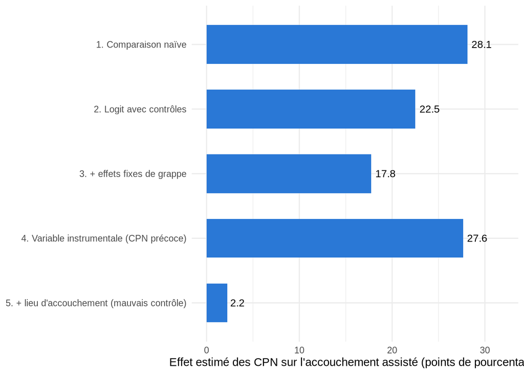

```r
ggplot(bilan, aes(x = effet_points, y = fct_rev(methode))) +
  geom_col(width = 0.6, fill = "#2a78d6") +
  geom_text(aes(label = round(effet_points, 1)), hjust = -0.2, size = 3.5) +
  scale_x_continuous(limits = c(0, 32)) +
  labs(x = "Effet estimé des CPN sur l'accouchement assisté (points de pourcentage)",
       y = NULL) +
  theme_minimal()
```

Avec de vraies données, il n’y a pas de ligne « vraie valeur » à tracer. On ne peut que **rendre explicites les hypothèses** de chaque estimation et voir si la conclusion y résiste. Ici, de 18 à 28 points selon la méthode, la conclusion tient : les CPN augmentent l’accouchement assisté. Seul le mauvais contrôle la renverse, et pour une mauvaise raison.

> **À vous (6).** Classez les sources de biais rencontrées (confusion observée, confusion locale non observée, confusion individuelle non observée, mauvais contrôle) selon la méthode qui permet de les traiter. Laquelle reste la plus difficile avec une EDS ?

> **À vous (7), pour votre équipe.** Refaites C1 à C8 avec l’EDS la plus récente de votre pays (`preparer_eds("donnees/XXIRxxFL.DTA")`). Vérifiez d’abord les catégories de `m3a` à `m3n` et de `m15`. La conclusion est-elle la même qu’au Ghana en 2003 ?

# 6 Partie D — Pour aller plus loin : prédire n’est pas expliquer

Supposons maintenant que l’objectif soit de **prédire** quelles femmes risquent d’accoucher sans assistance, pour cibler une campagne. Le meilleur modèle n’est plus le même.

```r
set.seed(2026)
eds_part <- eds %>% mutate(echantillon = if_else(runif(n()) < 0.7, "apprentissage", "test"))
appr <- eds_part %>% filter(echantillon == "apprentissage")
test <- eds_part %>% filter(echantillon == "test")

precision <- function(formule) {
  m <- glm(formule, family = binomial, data = appr)
  pred <- predict(m, newdata = test, type = "response") > 0.5
  mean(pred == (test$acc_assiste == 1))
}

tibble(
  modele = c("Modèle causal (contrôles avant traitement)",
             "Modèle avec le lieu d'accouchement"),
  precision_test = c(
    precision(acc_assiste ~ cpn4 + age + instruction + quintile + parite + distance_pb + radio + region),
    precision(acc_assiste ~ cpn4 + centre_sante + age + instruction + quintile + parite + distance_pb + radio + region)
  )
)
```

```
## # A tibble: 2 × 2
##   modele                                     precision_test
##   <chr>                                               <dbl>
## 1 Modèle causal (contrôles avant traitement)          0.746
## 2 Modèle avec le lieu d'accouchement                  0.984
```

Le lieu d’accouchement améliore nettement la prédiction alors qu’il fausse l’effet causal. **Décrire, prédire et expliquer sont trois tâches différentes**, qui n’appellent pas les mêmes modèles ni les mêmes variables (Hernán, Hsu et Healy, 2019).

> **À vous (8).** Pour la note de votre pays, quelle tâche votre institut remplit-il le plus souvent : décrire, prédire ou expliquer ? Donnez un exemple de question pour chacune.

# 7 Références

- Adjiwanou, V. et LeGrand, T. (2013). Does antenatal care matter in the use of skilled birth attendance in rural Africa: A multi-country analysis. *Social Science & Medicine*, 86, 26-34.
- Adjiwanou, V., Bougma, M. et LeGrand, T. (2018). The effect of partners’ education on women’s reproductive and maternal health in developing countries. *Social Science & Medicine*, 197, 104-115.
- Adjiwanou, V., Boco, G. A. et Yaya, S. (2021). Stepfather families and children’s schooling in sub-Saharan Africa: A cross-national study. *Demographic Research*, 44(27), 627-670.
- Adjiwanou, V. et N’Bouke, A. (2015). Exploring the paradox of intimate partner violence and increased contraceptive use in sub-Saharan Africa. *Studies in Family Planning*, 46(2), 127-142.
- Bertrand, M. et Mullainathan, S. (2004). Are Emily and Greg more employable than Lakisha and Jamal? *American Economic Review*, 94(4), 991-1013.
- Card, D. et Krueger, A. B. (1994). Minimum wages and employment: A case study of the fast-food industry in New Jersey and Pennsylvania. *American Economic Review*, 84(4), 772-793.
- Ghana Statistical Service, Noguchi Memorial Institute for Medical Research et ORC Macro (2004). *Ghana Demographic and Health Survey 2003*. Calverton, ORC Macro.
- Hernán, M. A., Hsu, J. et Healy, B. (2019). A second chance to get causal inference right: A classification of data science tasks. *Chance*, 32(1), 42-49.
- Imai, K. (2017). *Quantitative Social Science: An Introduction*. Princeton University Press. Les données `resume` et `minwage` viennent de ce manuel.